# Trabajo Final — Réplica en R

*Imágenes originales de la carpeta `.fig`: no se recalculan porque requieren los microdatos.*

**Figura A10.** Descomposición KS del cambio en la brecha de la pobreza y de la pobreza extrema por área geográfica en Colombia 2002-2018. Puntos porcentuales.

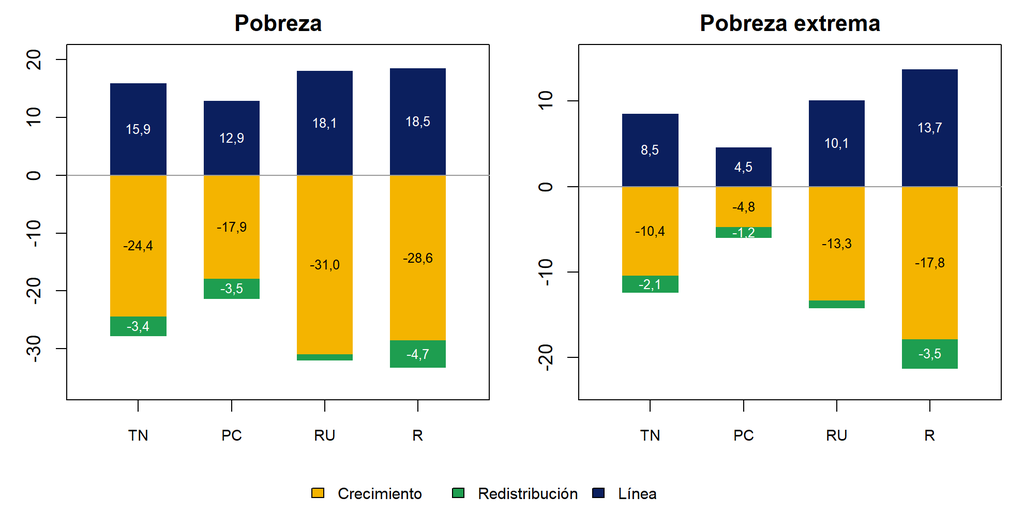

```r
f_ks(2)
```

**Figura A11.** Descomposición KS del cambio en la severidad de la pobreza y de la pobreza extrema por área geográfica en Colombia 2002-2018. Puntos porcentuales.

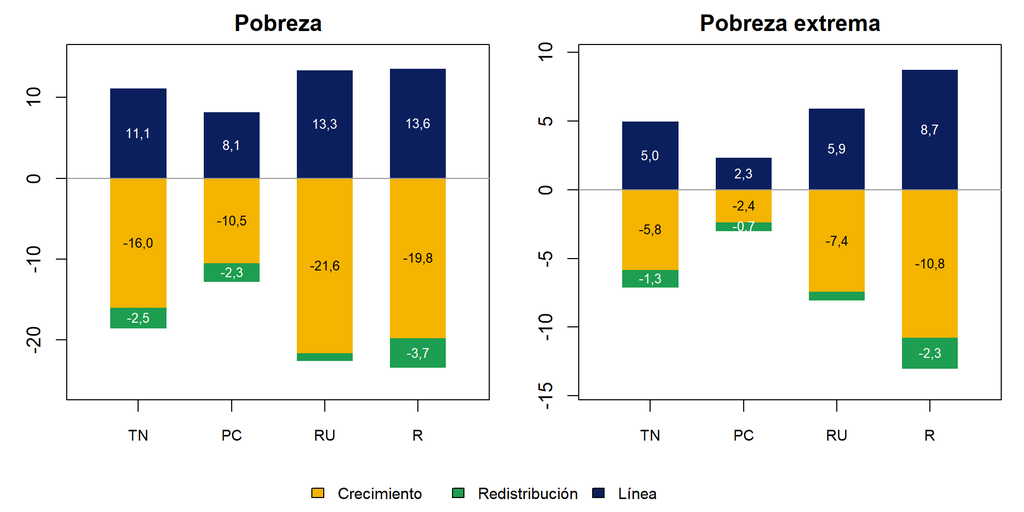

```r
f_ks(3)
```

**Figura A12.** Descomposición KS del cambio en la brecha de la pobreza y de la pobreza extrema por ciudades principales en Colombia 2002-2018. Puntos porcentuales.

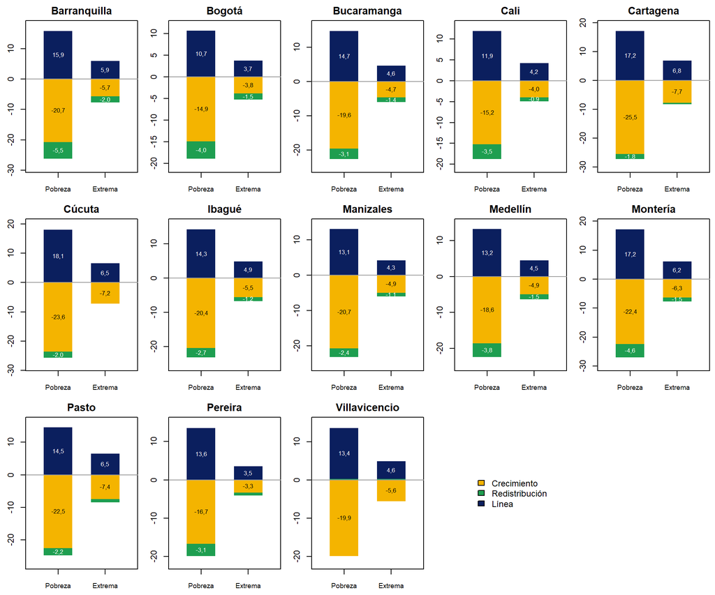

```r
f_ks_ciu(2)
```

**Figura A13.** Descomposición KS del cambio en la severidad de la pobreza y de la pobreza extrema por ciudades principales en Colombia 2002-2018. Puntos porcentuales.

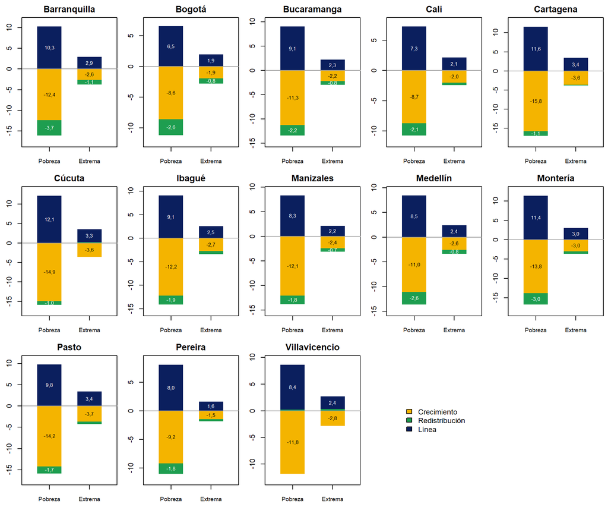

```r
f_ks_ciu(3)
```

**Figura A14.** Función de distribución del logaritmo del ingreso per cápita de la unidad de gasto para el agregado nacional del escenario original y de los escenarios contrafácticos.

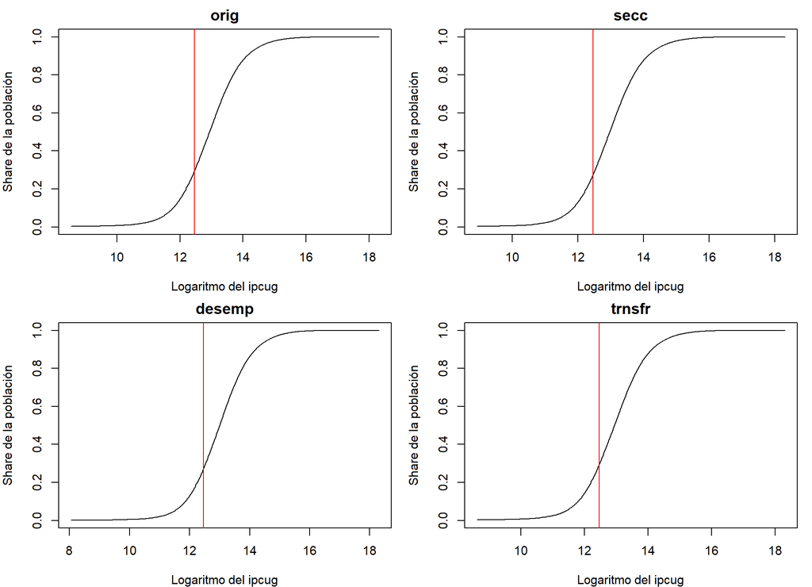

```r
f_cdf()
```

# B. Tablas adicionales

**Tabla B1.** Participación de cada área geográfica en la población en Colombia 2002-2018. Valores porcentuales.

```r
tB1()
```

| Año | Principales ciudades | Resto urbano | Rural | Total nacional |
| --- | --- | --- | --- | --- |
| 2002 | 44,32 | 29,63 | 26,05 | 100,00 |
| 2003 | 44,45 | 29,86 | 25,69 | 100,00 |
| 2004 | 44,57 | 30,07 | 25,36 | 100,00 |
| 2005 | 44,69 | 30,26 | 25,04 | 100,00 |
| 2008 | 44,98 | 30,73 | 24,29 | 100,00 |
| 2009 | 45,06 | 30,86 | 24,08 | 100,00 |
| 2010 | 45,14 | 31,00 | 23,86 | 100,00 |
| 2011 | 45,22 | 31,12 | 23,67 | 100,00 |
| 2012 | 45,28 | 31,21 | 23,51 | 100,00 |
| 2013 | 45,34 | 31,32 | 23,34 | 100,00 |
| 2014 | 45,40 | 31,42 | 23,17 | 100,00 |
| 2015 | 45,45 | 31,52 | 23,02 | 100,00 |
| 2016 | 45,50 | 31,62 | 22,88 | 100,00 |
| 2017 | 46,06 | 31,19 | 22,75 | 100,00 |
| 2018 | 45,57 | 31,80 | 22,63 | 100,00 |

**Tabla B2.** Participación de cada área geográfica en los indicadores de pobreza extrema FGT en Colombia 2002-2018. Valores porcentuales.

```r
t7('B2', 2)
```

| Año | Indicador | Principales ciudades | Resto urbano | Rural | Total nacional |
| --- | --- | --- | --- | --- | --- |
| 2002 | Incidencia | 18,7 | 32,8 | 48,5 | 100,0 |
| 2002 | Brecha | 17,9 | 30,6 | 51,5 | 100,0 |
| 2002 | Severidad | 18,7 | 29,5 | 51,8 | 100,0 |
| 2003 | Incidencia | 20,9 | 31,9 | 47,2 | 100,0 |
| 2003 | Brecha | 20,1 | 31,4 | 48,5 | 100,0 |
| 2003 | Severidad | 20,7 | 31,2 | 48,1 | 100,0 |
| 2004 | Incidencia | 19,6 | 30,7 | 49,6 | 100,0 |
| 2004 | Brecha | 20,1 | 28,9 | 51,1 | 100,0 |
| 2004 | Severidad | 21,7 | 27,6 | 50,7 | 100,0 |
| 2005 | Incidencia | 18,3 | 31,3 | 50,5 | 100,0 |
| 2005 | Brecha | 17,9 | 29,1 | 53,0 | 100,0 |
| 2005 | Severidad | 19,0 | 27,5 | 53,5 | 100,0 |
| 2008 | Incidencia | 15,3 | 35,9 | 48,8 | 100,0 |
| 2008 | Brecha | 14,0 | 34,9 | 51,1 | 100,0 |
| 2008 | Severidad | 14,3 | 34,6 | 51,1 | 100,0 |
| 2009 | Incidencia | 16,3 | 35,2 | 48,5 | 100,0 |
| 2009 | Brecha | 16,3 | 33,7 | 50,0 | 100,0 |
| 2009 | Severidad | 17,6 | 32,7 | 49,7 | 100,0 |
| 2010 | Incidencia | 17,1 | 33,4 | 49,5 | 100,0 |
| 2010 | Brecha | 17,7 | 31,2 | 51,1 | 100,0 |
| 2010 | Severidad | 19,5 | 29,6 | 51,0 | 100,0 |
| 2011 | Incidencia | 14,8 | 34,8 | 50,4 | 100,0 |
| 2011 | Brecha | 15,3 | 33,4 | 51,3 | 100,0 |
| 2011 | Severidad | 17,0 | 32,8 | 50,2 | 100,0 |
| 2012 | Incidencia | 14,4 | 34,1 | 51,4 | 100,0 |
| 2012 | Brecha | 14,7 | 33,0 | 52,3 | 100,0 |
| 2012 | Severidad | 15,8 | 32,8 | 51,4 | 100,0 |
| 2013 | Incidencia | 15,0 | 35,7 | 49,3 | 100,0 |
| 2013 | Brecha | 16,9 | 34,2 | 49,0 | 100,0 |
| 2013 | Severidad | 19,2 | 33,6 | 47,2 | 100,0 |
| 2014 | Incidencia | 14,9 | 33,4 | 51,7 | 100,0 |
| 2014 | Brecha | 16,6 | 32,2 | 51,2 | 100,0 |
| 2014 | Severidad | 19,2 | 32,1 | 48,8 | 100,0 |
| 2015 | Incidencia | 15,6 | 32,2 | 52,2 | 100,0 |
| 2015 | Brecha | 18,7 | 30,0 | 51,2 | 100,0 |
| 2015 | Severidad | 22,7 | 29,1 | 48,2 | 100,0 |
| 2016 | Incidencia | 15,7 | 35,3 | 49,0 | 100,0 |
| 2016 | Brecha | 18,0 | 34,5 | 47,5 | 100,0 |
| 2016 | Severidad | 20,8 | 34,6 | 44,7 | 100,0 |
| 2017 | Incidencia | 17,3 | 35,3 | 47,4 | 100,0 |
| 2017 | Brecha | 20,6 | 34,1 | 45,3 | 100,0 |
| 2017 | Severidad | 24,7 | 34,1 | 41,2 | 100,0 |
| 2018 | Incidencia | 17,9 | 34,1 | 48,0 | 100,0 |
| 2018 | Brecha | 21,0 | 32,2 | 46,9 | 100,0 |
| 2018 | Severidad | 24,9 | 30,9 | 44,2 | 100,0 |

**Tabla B3.** Brecha de la pobreza y de la pobreza extrema por ciudades principales en Colombia 2002- 2018.

```r
t8('B3', 2)
```

| Pobreza (FGT1) | 2002 | 2003 | 2004 | 2005 | 2008 | 2009 | 2010 | 2011 | 2012 | 2013 | 2014 | 2015 | 2016 | 2017 | 2018 |
| --- | --- | --- | --- | --- | --- | --- | --- | --- | --- | --- | --- | --- | --- | --- | --- |
| Barranquilla | 16,3 | 19,4 | 17,2 | 16,4 | 16,2 | 14,8 | 13,9 | 11,5 | 9,4 | 9,2 | 7,8 | 6,1 | 5,9 | 5,6 | 5,9 |
| Bogotá | 12,5 | 12,7 | 11,1 | 9,6 | 6,6 | 6,2 | 5,1 | 4,1 | 3,7 | 3,2 | 3,4 | 3,6 | 3,9 | 4,1 | 4,3 |
| Bucaramanga | 12,0 | 12,0 | 10,5 | 10,8 | 5,8 | 3,8 | 3,0 | 3,0 | 3,0 | 2,9 | 2,3 | 2,7 | 2,9 | 3,4 | 4,1 |
| Cali | 12,2 | 12,0 | 11,3 | 10,5 | 11,0 | 11,1 | 10,1 | 9,1 | 8,6 | 7,9 | 6,5 | 5,8 | 5,0 | 5,2 | 5,4 |
| Cartagena | 17,9 | 15,9 | 16,0 | 12,3 | 13,9 | 13,3 | 12,0 | 10,8 | 11,2 | 10,3 | 8,7 | 8,1 | 9,7 | 8,5 | 7,8 |
| Cúcuta | 20,4 | 23,2 | 23,1 | 21,5 | 15,1 | 13,4 | 15,1 | 11,6 | 11,0 | 11,4 | 11,8 | 11,8 | 12,1 | 11,4 | 12,8 |
| Ibagué | 14,6 | 15,9 | 17,4 | 15,1 | 12,0 | 9,8 | 9,0 | 6,7 | 6,8 | 5,8 | 5,2 | 5,4 | 5,2 | 5,6 | 5,9 |
| Manizales | 14,1 | 15,4 | 16,3 | 14,0 | 11,7 | 10,6 | 8,5 | 6,0 | 5,6 | 5,3 | 5,2 | 4,3 | 4,8 | 4,3 | 4,0 |
| Medellín | 14,1 | 13,1 | 11,6 | 10,3 | 9,5 | 9,3 | 8,4 | 6,9 | 6,2 | 5,8 | 5,1 | 5,3 | 5,0 | 4,5 | 4,8 |
| Montería | 18,8 | 20,3 | 20,0 | 18,4 | 14,0 | 12,9 | 13,7 | 13,2 | 13,0 | 12,3 | 5,6 | 6,9 | 9,5 | 9,9 | 9,0 |
| Pasto | 18,5 | 19,1 | 18,3 | 18,5 | 15,4 | 16,5 | 17,3 | 15,0 | 13,7 | 10,1 | 8,7 | 8,1 | 6,9 | 6,1 | 8,3 |
| Pereira | 10,5 | 9,3 | 9,1 | 9,2 | 9,3 | 9,4 | 8,8 | 6,4 | 6,8 | 8,8 | 5,7 | 5,3 | 4,4 | 3,2 | 4,2 |
| Villavicencio | 12,8 | 13,3 | 11,4 | 12,6 | 9,7 | 9,8 | 9,0 | 7,8 | 7,6 | 6,6 | 5,6 | 5,8 | 7,2 | 7,0 | 6,5 |

| Pobreza extrema (FGT1) | 2002 | 2003 | 2004 | 2005 | 2008 | 2009 | 2010 | 2011 | 2012 | 2013 | 2014 | 2015 | 2016 | 2017 | 2018 |
| --- | --- | --- | --- | --- | --- | --- | --- | --- | --- | --- | --- | --- | --- | --- | --- |
| Barranquilla | 2,4 | 3,1 | 2,4 | 2,3 | 3,0 | 2,5 | 2,3 | 1,7 | 1,2 | 1,3 | 1,1 | 0,8 | 0,8 | 0,6 | 0,6 |
| Bogotá | 2,8 | 2,7 | 2,5 | 1,7 | 1,3 | 1,4 | 1,1 | 0,7 | 0,8 | 0,7 | 0,8 | 1,0 | 1,1 | 1,2 | 1,3 |
| Bucaramanga | 2,2 | 1,8 | 1,5 | 1,8 | 0,9 | 0,6 | 0,4 | 0,5 | 0,5 | 0,6 | 0,4 | 0,6 | 0,5 | 0,7 | 0,7 |
| Cali | 2,2 | 1,9 | 1,9 | 1,8 | 3,1 | 3,0 | 2,9 | 2,2 | 2,1 | 2,0 | 1,6 | 1,5 | 1,3 | 1,4 | 1,5 |
| Cartagena | 2,5 | 2,1 | 1,9 | 1,1 | 1,9 | 2,0 | 2,1 | 1,3 | 2,0 | 2,2 | 1,6 | 1,4 | 2,0 | 1,4 | 1,1 |
| Cúcuta | 3,5 | 4,1 | 4,6 | 3,7 | 2,6 | 2,5 | 3,3 | 2,2 | 2,0 | 2,4 | 2,4 | 2,8 | 2,8 | 2,0 | 2,8 |
| Ibagué | 2,9 | 3,6 | 3,8 | 3,0 | 2,5 | 1,7 | 1,3 | 1,0 | 0,9 | 0,9 | 0,8 | 0,8 | 0,9 | 1,0 | 1,1 |
| Manizales | 2,8 | 2,8 | 3,6 | 2,9 | 2,8 | 2,6 | 1,9 | 0,8 | 0,8 | 0,8 | 0,8 | 0,9 | 1,1 | 0,9 | 1,0 |
| Medellín | 3,1 | 2,6 | 2,3 | 1,7 | 2,8 | 2,6 | 2,4 | 1,6 | 1,3 | 1,4 | 1,2 | 1,5 | 1,4 | 1,2 | 1,2 |
| Montería | 2,8 | 3,1 | 2,9 | 2,8 | 1,8 | 1,7 | 2,0 | 2,0 | 2,0 | 2,0 | 0,4 | 0,7 | 1,4 | 2,3 | 1,3 |
| Pasto | 3,3 | 3,2 | 2,9 | 3,4 | 2,8 | 3,1 | 3,6 | 2,5 | 2,4 | 1,3 | 1,4 | 1,4 | 0,9 | 0,9 | 1,3 |
| Pereira | 1,3 | 1,1 | 1,1 | 1,1 | 1,5 | 1,5 | 1,3 | 0,8 | 1,0 | 2,2 | 1,0 | 0,8 | 0,6 | 0,3 | 0,7 |
| Villavicencio | 2,7 | 2,6 | 1,9 | 2,5 | 2,2 | 2,2 | 2,0 | 1,9 | 1,9 | 1,6 | 1,5 | 1,4 | 2,3 | 2,3 | 1,9 |

**Tabla B4.** Severidad de la pobreza y de la pobreza extrema por ciudades principales en Colombia 2002-2018.

```r
t8('B4', 3)
```

| Pobreza (FGT2) | 2002 | 2003 | 2004 | 2005 | 2008 | 2009 | 2010 | 2011 | 2012 | 2013 | 2014 | 2015 | 2016 | 2017 | 2018 |
| --- | --- | --- | --- | --- | --- | --- | --- | --- | --- | --- | --- | --- | --- | --- | --- |
| Barranquilla | 8,3 | 10,1 | 8,7 | 8,2 | 8,3 | 7,3 | 6,9 | 5,5 | 4,2 | 4,3 | 3,6 | 2,6 | 2,6 | 2,4 | 2,5 |
| Bogotá | 7,0 | 7,0 | 6,1 | 5,0 | 3,3 | 3,2 | 2,6 | 2,0 | 1,9 | 1,6 | 1,8 | 1,9 | 2,1 | 2,2 | 2,4 |
| Bucaramanga | 6,3 | 6,0 | 5,2 | 5,5 | 2,7 | 1,7 | 1,3 | 1,4 | 1,3 | 1,4 | 1,1 | 1,3 | 1,3 | 1,6 | 1,9 |
| Cali | 6,4 | 6,1 | 5,8 | 5,3 | 6,2 | 6,3 | 5,8 | 4,9 | 4,7 | 4,3 | 3,4 | 3,1 | 2,6 | 2,8 | 2,9 |
| Cartagena | 9,0 | 7,8 | 7,7 | 5,6 | 6,6 | 6,4 | 6,0 | 5,0 | 5,5 | 5,4 | 4,2 | 3,9 | 4,9 | 4,0 | 3,6 |
| Cúcuta | 10,6 | 12,5 | 12,7 | 11,4 | 7,6 | 6,8 | 8,1 | 5,9 | 5,6 | 6,1 | 6,2 | 6,4 | 6,4 | 5,7 | 6,8 |
| Ibagué | 7,9 | 8,9 | 9,7 | 8,1 | 6,3 | 4,9 | 4,4 | 3,1 | 3,1 | 2,7 | 2,5 | 2,5 | 2,4 | 2,7 | 2,9 |
| Manizales | 7,6 | 8,3 | 9,1 | 7,6 | 6,3 | 5,8 | 4,5 | 2,8 | 2,7 | 2,6 | 2,6 | 2,2 | 2,4 | 2,2 | 2,2 |
| Medellín | 7,8 | 7,0 | 6,1 | 5,2 | 5,4 | 5,3 | 4,8 | 3,7 | 3,3 | 3,1 | 2,8 | 3,0 | 2,8 | 2,4 | 2,6 |
| Montería | 9,7 | 10,6 | 10,4 | 9,6 | 6,7 | 6,1 | 6,7 | 6,4 | 6,4 | 6,2 | 2,2 | 2,8 | 4,4 | 5,1 | 4,3 |
| Pasto | 10,0 | 10,1 | 9,6 | 9,9 | 8,0 | 8,6 | 9,5 | 7,6 | 7,0 | 4,7 | 4,2 | 3,9 | 3,1 | 2,8 | 3,9 |
| Pereira | 4,9 | 4,3 | 4,2 | 4,3 | 4,5 | 4,6 | 4,3 | 2,9 | 3,2 | 4,8 | 2,8 | 2,5 | 1,9 | 1,3 | 1,9 |
| Villavicencio | 6,8 | 7,0 | 5,8 | 6,6 | 5,2 | 5,2 | 4,8 | 4,1 | 4,1 | 3,5 | 3,1 | 3,1 | 4,0 | 4,0 | 3,6 |

| Pobreza extrema (FGT2) | 2002 | 2003 | 2004 | 2005 | 2008 | 2009 | 2010 | 2011 | 2012 | 2013 | 2014 | 2015 | 2016 | 2017 | 2018 |
| --- | --- | --- | --- | --- | --- | --- | --- | --- | --- | --- | --- | --- | --- | --- | --- |
| Barranquilla | 1,1 | 1,4 | 1,1 | 1,1 | 1,5 | 1,2 | 1,1 | 0,8 | 0,6 | 0,7 | 0,5 | 0,4 | 0,4 | 0,3 | 0,3 |
| Bogotá | 1,8 | 1,7 | 1,6 | 1,0 | 0,8 | 0,9 | 0,7 | 0,4 | 0,5 | 0,5 | 0,6 | 0,7 | 0,8 | 0,9 | 1,0 |
| Bucaramanga | 1,3 | 0,9 | 0,8 | 1,0 | 0,5 | 0,3 | 0,2 | 0,4 | 0,3 | 0,4 | 0,3 | 0,4 | 0,3 | 0,5 | 0,5 |
| Cali | 1,3 | 1,0 | 1,1 | 1,0 | 2,0 | 1,8 | 1,9 | 1,4 | 1,2 | 1,3 | 1,1 | 1,1 | 0,8 | 0,9 | 1,0 |
| Cartagena | 1,0 | 0,9 | 0,8 | 0,5 | 0,8 | 1,0 | 1,1 | 0,6 | 1,1 | 1,3 | 0,9 | 0,8 | 1,2 | 0,8 | 0,6 |
| Cúcuta | 1,8 | 2,0 | 2,4 | 1,9 | 1,4 | 1,4 | 1,9 | 1,3 | 1,2 | 1,5 | 1,5 | 1,9 | 1,8 | 1,2 | 1,8 |
| Ibagué | 1,5 | 2,0 | 2,1 | 1,6 | 1,4 | 0,9 | 0,6 | 0,6 | 0,5 | 0,5 | 0,5 | 0,4 | 0,5 | 0,6 | 0,7 |
| Manizales | 1,7 | 1,6 | 2,1 | 1,7 | 1,7 | 1,5 | 1,1 | 0,5 | 0,4 | 0,4 | 0,5 | 0,6 | 0,7 | 0,6 | 0,8 |
| Medellín | 1,8 | 1,5 | 1,4 | 1,0 | 1,8 | 1,6 | 1,5 | 1,0 | 0,8 | 0,9 | 0,8 | 1,0 | 0,9 | 0,8 | 0,8 |
| Montería | 1,3 | 1,3 | 1,3 | 1,4 | 0,9 | 0,8 | 1,0 | 1,0 | 1,1 | 1,0 | 0,2 | 0,4 | 0,7 | 1,4 | 0,7 |
| Pasto | 1,5 | 1,4 | 1,3 | 1,5 | 1,2 | 1,5 | 1,8 | 1,2 | 1,1 | 0,6 | 0,7 | 0,8 | 0,4 | 0,5 | 0,7 |
| Pereira | 0,6 | 0,7 | 0,6 | 0,6 | 0,8 | 0,9 | 0,8 | 0,4 | 0,5 | 1,4 | 0,7 | 0,5 | 0,3 | 0,2 | 0,4 |
| Villavicencio | 1,5 | 1,6 | 1,1 | 1,6 | 1,5 | 1,5 | 1,3 | 1,3 | 1,3 | 1,2 | 1,1 | 1,0 | 1,6 | 1,6 | 1,4 |

**Tabla B5.** Variación de la brecha de la pobreza y de la pobreza extrema por ciudades principales en Colombia 2002-2018. Puntos porcentuales.

```r
t9('B5', 2)
```

| Ciudad | Pobreza 2002-2005 | Pobreza 2008-2018 | Pobreza 2002-2018 | Extrema 2002-2005 | Extrema 2008-2018 | Extrema 2002-2018 |
| --- | --- | --- | --- | --- | --- | --- |
| Barranquilla | 0,1 | -10,3 | -10,4 | -0,1 | -2,4 | -1,8 |
| Bogotá | -2,9 | -2,3 | -8,3 | -1,1 | -0,0 | -1,6 |
| Bucaramanga | -1,2 | -1,7 | -8,0 | -0,4 | -0,1 | -1,5 |
| Cali | -1,8 | -5,6 | -6,8 | -0,5 | -1,6 | -0,7 |
| Cartagena | -5,6 | -6,1 | -10,1 | -1,4 | -0,8 | -1,4 |
| Cúcuta | 1,1 | -2,2 | -7,6 | 0,2 | 0,2 | -0,7 |
| Ibagué | 0,5 | -6,2 | -8,8 | 0,1 | -1,4 | -1,8 |
| Manizales | -0,1 | -7,6 | -10,0 | 0,1 | -1,8 | -1,8 |
| Medellín | -3,8 | -4,7 | -9,2 | -1,3 | -1,6 | -1,9 |
| Montería | -0,4 | -5,0 | -9,8 | 0,0 | -0,5 | -1,6 |
| Pasto | -0,0 | -7,1 | -10,2 | 0,1 | -1,4 | -1,9 |
| Pereira | -1,3 | -5,1 | -6,3 | -0,2 | -0,8 | -0,6 |
| Villavicencio | -0,1 | -3,2 | -6,3 | -0,2 | -0,3 | -0,8 |

**Tabla B6.** Variación de la severidad de la pobreza y de la pobreza extrema por ciudades principales en Colombia 2002-2018. Puntos porcentuales.

```r
t9('B6', 3)
```

| Ciudad | Pobreza 2002-2005 | Pobreza 2008-2018 | Pobreza 2002-2018 | Extrema 2002-2005 | Extrema 2008-2018 | Extrema 2002-2018 |
| --- | --- | --- | --- | --- | --- | --- |
| Barranquilla | -0,0 | -5,9 | -5,8 | -0,0 | -1,3 | -0,8 |
| Bogotá | -2,0 | -1,0 | -4,7 | -0,8 | 0,1 | -0,9 |
| Bucaramanga | -0,8 | -0,8 | -4,4 | -0,2 | 0,0 | -0,7 |
| Cali | -1,2 | -3,3 | -3,5 | -0,3 | -1,0 | -0,3 |
| Cartagena | -3,4 | -3,0 | -5,4 | -0,5 | -0,2 | -0,4 |
| Cúcuta | 0,7 | -0,8 | -3,8 | 0,1 | 0,3 | -0,1 |
| Ibagué | 0,2 | -3,4 | -5,0 | 0,1 | -0,7 | -0,9 |
| Manizales | -0,0 | -4,1 | -5,5 | -0,0 | -1,0 | -1,0 |
| Medellín | -2,5 | -2,8 | -5,1 | -0,8 | -1,0 | -1,0 |
| Montería | -0,1 | -2,4 | -5,4 | 0,1 | -0,2 | -0,6 |
| Pasto | -0,1 | -4,1 | -6,1 | -0,0 | -0,5 | -0,8 |
| Pereira | -0,6 | -2,6 | -3,0 | -0,0 | -0,4 | -0,2 |
| Villavicencio | -0,2 | -1,5 | -3,2 | 0,0 | -0,1 | -0,1 |

**Tabla B7.** Incidencia de la pobreza extrema según características del jefe de hogar por área geográfica en Colombia 2002 y 2018.

```r
t10('B7', 'i', 'cjh')
```

| Característica | 2002 TN | 2002 PC | 2002 RU | 2002 R | 2018 TN | 2018 PC | 2018 RU | 2018 R | Var. TN | Var. PC | Var. RU | Var. R |
| --- | --- | --- | --- | --- | --- | --- | --- | --- | --- | --- | --- | --- |
| Sexo: hombre | 18,0 | 6,9 | 19,0 | 33,3 | 6,5 | 2,2 | 6,3 | 14,0 | -11,4 | -4,7 | -12,7 | -19,2 |
| Sexo: mujer | 16,6 | 9,1 | 21,2 | 30,1 | 8,6 | 4,0 | 10,2 | 19,8 | -8,0 | -5,1 | -11,0 | -10,3 |
| Edad: [0,25] | 21,6 | 12,2 | 24,3 | 33,5 | 9,5 | 4,2 | 9,1 | 18,0 | -12,1 | -8,0 | -15,3 | -15,5 |
| Edad: [26,35] | 21,0 | 11,1 | 23,2 | 34,5 | 9,4 | 4,0 | 10,4 | 18,3 | -11,5 | -7,1 | -12,8 | -16,2 |
| Edad: [36,45] | 19,2 | 6,8 | 23,1 | 36,3 | 8,0 | 3,5 | 8,0 | 16,4 | -11,2 | -3,3 | -15,1 | -19,9 |
| Edad: [46,55] | 13,7 | 5,6 | 14,4 | 28,6 | 6,6 | 2,2 | 7,5 | 14,2 | -7,1 | -3,4 | -6,8 | -14,4 |
| Edad: [56,65] | 15,5 | 6,5 | 16,7 | 28,2 | 5,4 | 2,2 | 6,0 | 12,6 | -10,0 | -4,4 | -10,7 | -15,6 |
| Edad: [65+] | 16,6 | 6,1 | 16,1 | 34,0 | 5,2 | 1,8 | 5,5 | 12,5 | -11,4 | -4,2 | -10,5 | -21,5 |
| Educación: prim. incomp. | 29,2 | 13,9 | 28,2 | 37,6 | 13,5 | 5,2 | 12,8 | 18,6 | -15,7 | -8,8 | -15,4 | -19,1 |
| Educación: prim. comp. | 19,0 | 9,2 | 21,7 | 31,1 | 8,1 | 3,3 | 8,3 | 14,3 | -10,8 | -5,9 | -13,4 | -16,7 |
| Educación: sec. incomp. | 13,8 | 9,1 | 18,4 | 22,8 | 7,5 | 3,7 | 9,5 | 13,1 | -6,3 | -5,5 | -8,9 | -9,7 |
| Educación: sec. comp. | 6,2 | 3,8 | 8,5 | 15,5 | 4,9 | 2,6 | 6,3 | 11,6 | -1,4 | -1,2 | -2,2 | -3,9 |
| Educación: sup. incomp. | 2,9 | 1,9 | 6,7 | 0,0 | 2,7 | 1,9 | 3,6 | 5,6 | -0,2 | -0,0 | -3,1 | 5,6 |
| Educación: sup. comp. | 2,0 | 1,4 | 2,3 | 7,2 | 0,9 | 0,8 | 1,1 | 1,5 | -1,1 | -0,6 | -1,2 | -5,6 |
| Estado: ocupado | 16,7 | 5,9 | 18,0 | 31,6 | 6,2 | 1,7 | 6,1 | 14,2 | -10,5 | -4,2 | -11,8 | -17,4 |
| Estado: desocupado | 32,1 | 23,5 | 38,7 | 47,9 | 21,4 | 16,2 | 26,6 | 29,9 | -10,6 | -7,3 | -12,1 | -18,0 |
| Estado: inactivo | 16,3 | 6,8 | 19,0 | 35,8 | 8,3 | 3,7 | 9,3 | 20,7 | -8,0 | -3,1 | -9,7 | -15,0 |
| Categoría: asalariado | 5,8 | 2,7 | 11,0 | 6,9 | 1,0 | 0,6 | 1,6 | 1,0 | -4,8 | -2,0 | -9,4 | -6,0 |
| Categoría: cuenta propia o patrón | 23,2 | 8,8 | 21,7 | 42,8 | 10,2 | 3,0 | 8,9 | 20,6 | -13,0 | -5,9 | -12,9 | -22,2 |

**Tabla B8.** Incidencia de la pobreza extrema según características del hogar por área geográfica en Colombia 2002 y 2018.

```r
t10('B8', 'i', 'ch')
```

| Característica | 2002 TN | 2002 PC | 2002 RU | 2002 R | 2018 TN | 2018 PC | 2018 RU | 2018 R | Var. TN | Var. PC | Var. RU | Var. R |
| --- | --- | --- | --- | --- | --- | --- | --- | --- | --- | --- | --- | --- |
| Niños menores de 12: ninguno | 7,5 | 3,0 | 8,4 | 17,8 | 3,5 | 1,7 | 3,7 | 7,9 | -4,1 | -1,2 | -4,7 | -9,9 |
| Niños menores de 12: uno | 12,3 | 5,3 | 12,7 | 26,2 | 5,6 | 2,4 | 6,2 | 11,3 | -6,7 | -2,9 | -6,5 | -15,0 |
| Niños menores de 12: dos | 18,9 | 8,9 | 21,3 | 31,6 | 10,0 | 3,8 | 10,7 | 18,4 | -8,9 | -5,0 | -10,6 | -13,3 |
| Niños menores de 12: tres o más | 38,4 | 21,6 | 38,4 | 52,0 | 23,6 | 10,9 | 22,1 | 35,5 | -14,8 | -10,7 | -16,3 | -16,5 |
| Ocupados: ninguno | 30,3 | 23,0 | 32,6 | 45,1 | 21,0 | 15,4 | 22,6 | 34,1 | -9,3 | -7,6 | -10,0 | -11,0 |
| Ocupados: uno | 22,8 | 10,2 | 25,4 | 39,0 | 9,5 | 3,6 | 10,2 | 17,7 | -13,3 | -6,6 | -15,2 | -21,3 |
| Ocupados: dos o más | 12,9 | 4,0 | 13,5 | 27,8 | 4,1 | 0,9 | 3,9 | 11,8 | -8,8 | -3,1 | -9,5 | -16,1 |
| Miembros: uno | 6,3 | 4,1 | 7,9 | 8,3 | 4,3 | 3,4 | 4,1 | 6,8 | -2,0 | -0,7 | -3,8 | -1,5 |
| Miembros: dos | 8,2 | 3,8 | 9,9 | 16,2 | 3,7 | 2,2 | 3,7 | 7,5 | -4,6 | -1,6 | -6,1 | -8,7 |
| Miembros: tres | 9,1 | 4,8 | 9,3 | 19,7 | 4,6 | 2,4 | 5,0 | 9,6 | -4,4 | -2,4 | -4,3 | -10,1 |
| Miembros: cuatro o más | 20,2 | 8,4 | 22,4 | 36,1 | 9,0 | 3,1 | 9,7 | 18,8 | -11,2 | -5,3 | -12,7 | -17,4 |

**Tabla B9.** Descomposición KS del cambio en la brecha de la pobreza y de la pobreza extrema por ciudades principales en Colombia 2002-2018.

```r
t15('B9', 2)
```

| Ciudad | Pobreza C | Pobreza R | Pobreza L | Pobreza T | Extrema C | Extrema R | Extrema L | Extrema T |
| --- | --- | --- | --- | --- | --- | --- | --- | --- |
| Barranquilla | -20,7 | -5,5 | 15,9 | -10,4 | -5,7 | -2,0 | 5,9 | -1,8 |
| Bogotá | -14,9 | -4,0 | 10,7 | -8,3 | -3,8 | -1,5 | 3,7 | -1,6 |
| Bucaramanga | -19,6 | -3,1 | 14,7 | -8,0 | -4,7 | -1,4 | 4,6 | -1,5 |
| Cali | -15,2 | -3,5 | 11,9 | -6,8 | -4,0 | -0,9 | 4,2 | -0,7 |
| Cartagena | -25,5 | -1,8 | 17,2 | -10,1 | -7,7 | -0,5 | 6,8 | -1,4 |
| Cúcuta | -23,6 | -2,0 | 18,1 | -7,6 | -7,2 | -0,1 | 6,5 | -0,7 |
| Ibagué | -20,4 | -2,7 | 14,3 | -8,8 | -5,5 | -1,2 | 4,9 | -1,8 |
| Manizales | -20,7 | -2,4 | 13,1 | -10,0 | -4,9 | -1,1 | 4,3 | -1,8 |
| Medellín | -18,6 | -3,8 | 13,2 | -9,2 | -4,9 | -1,5 | 4,5 | -1,9 |
| Montería | -22,4 | -4,6 | 17,2 | -9,8 | -6,3 | -1,5 | 6,2 | -1,6 |
| Pasto | -22,5 | -2,2 | 14,5 | -10,2 | -7,4 | -1,0 | 6,5 | -1,9 |
| Pereira | -16,7 | -3,1 | 13,6 | -6,3 | -3,3 | -0,8 | 3,5 | -0,6 |
| Villavicencio | -19,9 | 0,2 | 13,4 | -6,3 | -5,6 | 0,3 | 4,6 | -0,8 |

**Tabla B10.** Descomposición KS del cambio en la severidad de la pobreza y de la pobreza extrema por ciudades principales en Colombia 2002-2018.

```r
t15('B10', 3)
```

| Ciudad | Pobreza C | Pobreza R | Pobreza L | Pobreza T | Extrema C | Extrema R | Extrema L | Extrema T |
| --- | --- | --- | --- | --- | --- | --- | --- | --- |
| Barranquilla | -12,4 | -3,7 | 10,3 | -5,8 | -2,6 | -1,1 | 2,9 | -0,8 |
| Bogotá | -8,6 | -2,6 | 6,5 | -4,7 | -1,9 | -0,8 | 1,9 | -0,9 |
| Bucaramanga | -11,3 | -2,2 | 9,1 | -4,4 | -2,2 | -0,8 | 2,3 | -0,7 |
| Cali | -8,7 | -2,1 | 7,3 | -3,5 | -2,0 | -0,4 | 2,1 | -0,3 |
| Cartagena | -15,8 | -1,1 | 11,6 | -5,4 | -3,6 | -0,2 | 3,4 | -0,4 |
| Cúcuta | -14,9 | -1,0 | 12,1 | -3,8 | -3,6 | 0,2 | 3,3 | -0,1 |
| Ibagué | -12,2 | -1,9 | 9,1 | -5,0 | -2,7 | -0,7 | 2,5 | -0,9 |
| Manizales | -12,1 | -1,8 | 8,3 | -5,5 | -2,4 | -0,7 | 2,2 | -1,0 |
| Medellín | -11,0 | -2,6 | 8,5 | -5,1 | -2,6 | -0,8 | 2,4 | -1,0 |
| Montería | -13,8 | -3,0 | 11,4 | -5,4 | -3,0 | -0,7 | 3,0 | -0,6 |
| Pasto | -14,2 | -1,7 | 9,8 | -6,1 | -3,7 | -0,6 | 3,4 | -0,8 |
| Pereira | -9,2 | -1,8 | 8,0 | -3,0 | -1,5 | -0,3 | 1,6 | -0,2 |
| Villavicencio | -11,8 | 0,2 | 8,4 | -3,2 | -2,8 | 0,3 | 2,4 | -0,1 |

# Control de las cifras

Celdas de cada tabla comparadas entre el PDF y el valor reconstruido (tolerancia de media unidad del último decimal).

```r
ct <- do.call(rbind, lapply(names(control), function(n) data.frame(Tabla = n, Celdas = sum(control[[n]][, 1]), Distintas = sum(control[[n]][, 2]))))
ct <- ct[order(grepl("B", ct$Tabla), as.numeric(sub("B", "", ct$Tabla))), ]
tab(rbind(ct, data.frame(Tabla = "Total", Celdas = sum(ct$Celdas), Distintas = sum(ct$Distintas))))
```

| Tabla | Celdas | Distintas |
| --- | --- | --- |
| 1 | 139 | 0 |
| 2 | 189 | 0 |
| 3 | 180 | 0 |
| 4 | 180 | 0 |
| 5 | 36 | 0 |
| 6 | 36 | 0 |
| 7 | 180 | 0 |
| 8 | 390 | 0 |
| 9 | 78 | 0 |
| 10 | 228 | 0 |
| 11 | 132 | 0 |
| 12 | 60 | 0 |
| 13 | 288 | 0 |
| 14 | 96 | 0 |
| 15 | 104 | 0 |
| 16 | 144 | 2 |
| 17 | 168 | 0 |
| B1 | 60 | 0 |
| B2 | 180 | 0 |
| B3 | 390 | 0 |
| B4 | 390 | 0 |
| B5 | 78 | 0 |
| B6 | 78 | 0 |
| B7 | 228 | 0 |
| B8 | 132 | 0 |
| B9 | 104 | 0 |
| B10 | 104 | 0 |
| Total | 4372 | 2 |

**Coherencia interna.** La suma de los efectos crecimiento, redistribución y línea iguala el total en todas las descomposiciones KS (diferencia máxima 2e-06), y ese total coincide con el cambio de las tablas de pobreza:

```r
dif_area <- sapply(1:3, function(q) { y <- as.numeric(strsplit(periodos[q], "-")[[1]])
  max(sapply(1:4, function(j) sapply(1:2, function(l) abs(K[4, j, , l, q] - (fgt[[j]][(l - 1) * 3 + 1:3, match(y[2], anios)] - fgt[[j]][(l - 1) * 3 + 1:3, match(y[1], anios)]))))) })
dif_ciu <- sapply(1:3, function(q) { y <- as.numeric(strsplit(periodos[q], "-")[[1]])
  max(abs(KC[4, , , , q] - (FC[, , , match(y[2], anios)] - FC[, , , match(y[1], anios)]))) })
tab(data.frame(Período = periodos, "Áreas: máx. |KS - observado| (p.p.)" = num(dif_area, 4), "Ciudades: máx. |KS - observado| (p.p.)" = num(dif_ciu, 4), check.names = FALSE))
```

| Período | Áreas: máx. \|KS - observado\| (p.p.) | Ciudades: máx. \|KS - observado\| (p.p.) |
| --- | --- | --- |
| 2002-2005 | 0,0000 | 0,0000 |
| 2008-2018 | 0,0009 | 0,0025 |
| 2002-2018 | 0,0000 | 0,0000 |

**Con los ingresos individuales de 2018** (figura A14): el Gini nacional es 0,515 (tabla 12: 0,515) y la proporción de la población por debajo de la línea internacional de 1,9 dólares (66.589,7 pesos mensuales) es 2,93% (introducción: 2,9%).

[^1]: Licenciado en Economía - UNLP.
[^2]: Correspondiente a la línea internacional de pobreza (LIP), que define la pobreza monetaria extrema a efectos del seguimiento mundial.
[^3]: Siguiendo a Gasparini *et al*. (2013), más allá de los análisis mecánico y de asociaciones empíricas, un tercer nivel de análisis es el de las relaciones causales entre pobreza, crecimiento y desigualdad. La identificación de esos mecanismos es, naturalmente, de crucial importancia, pero también de una enorme complejidad.
[^4]: En este caso, el ingreso de todos los hogares crece a una misma tasa, por lo que la desigualdad no varía.
[^5]: Ver Medina y Galván (2014), para una revisión exhaustiva de las metodologías de descomposición.
[^6]: Estática en el sentido que predice el cambio en la pobreza frente a cambios en el ingreso y en el coeficiente de Gini en un período determinado y no a partir de la evolución en el tiempo de estas variables.
[^7]: Ver Datt y Ravallion (1992), para más detalles.
[^8]: Ambas encuestas (anteriormente ECG y actualmente GEIH) cubren población civil no institucional residente en todo el territorio nacional (áreas urbanas y rurales), representando alrededor del 99 por ciento de la población total del país y encontrándose dispersa en un poco más de la mitad de la superficie del país.
[^9]: A partir del segundo semestre de 2006, surgió un problema de comparabilidad en las series de empleo, pobreza y desigualdad como resultado del cambio metodológico que implicó la transición de la ECH a la GEIH. Para atender estas dificultades, que comprometían la credibilidad de indicadores fundamentales del mercado laboral y las condiciones de vida en Colombia, se inició un trabajo técnico del DANE y el DNP, que culminó en la creación de la MESEP.
[^10]: El ingreso corriente de la unidad de gasto incluye los ingresos monetarios y en especie que son devengados de manera constante por la unidad de gasto y excluye aquellos ingresos de carácter ocasional (ganancias ocasionales e intereses por cesantías).
[^11]: Cabe mencionar que las líneas de pobreza e indigencia se actualizan mensualmente, en la medida que avanza el relevamiento de la encuesta a lo largo del año. Adicionalmente, se tienen líneas de pobreza e indigencia por departamento y distinguiendo entre área urbana y rural.
[^12]: En las bases 2002 a 2005 de la MESEP, no es posible identificar informalidad, ya que, para los asalariados, no hay una variable relacionada a si están cotizando a un fondo de pensiones.
[^13]: Ver Apéndice A, para una descomposición RIF.
[^14]: Las “ayudas en el hogar” corresponden a ayudas en dinero: (i) de otros hogares o personas residentes del país o fuera del país; y (ii) de instituciones del país o fuera del país.
[^15]: En este trabajo, se tomarán en cuenta las siguientes cuatro áreas geográficas: (i) el total nacional; (ii) las trece ciudades principales y sus áreas metropolitanas; (iii) el resto urbano (es decir, el resto de ciudades y cabeceras urbanas); y (iv) los centros poblados y rural disperso.
[^16]: Adicionalmente, se realizaron ecuaciones de Mincer para los años 2008, 2015 y 2018 (resultados no mostrados), y lo que se observa es que la brecha salarial entre formales e informales aumenta de 2008 a 2018: en 2008, *céteris páribus*, los informales tenían, en promedio, un salario horario un 41,3% menor al de los formales, en tanto que, en 2018, este valor era de 44,8%. Por lo tanto, bajo este análisis, *céteris páribus*, aumenta la desigualdad salarial entre formales e informales.
[^17]: FGT hace referencia a los autores que propusieron estos indicadores para estudiar la pobreza monetaria: Foster, Greer y Thorbecke (1984).
[^18]: Notar que existe un índice de pobreza FGT para cada valor posible (cero o positivo) del parámetro 𝛼, cambiando las propiedades del índice dependiendo del 𝛼 considerado.
[^19]: También conocida como “intensidad” o “profundidad” de la pobreza.
[^20]: Ver Gasparini *et al*. (2013), p. 196, para una descripción de un conjunto de propiedades deseables para todo indicador de privaciones.
[^21]: Ver Figuras A1 y A2 en el Apéndice para los casos de brecha y de severidad (respectivamente) de la pobreza por área geográfica para el período 2002-2018.
[^22]: Ver Figuras A3 y A4 en el Apéndice para los casos de brecha y de severidad (respectivamente) de la pobreza extrema por área geográfica para el período 2002-2018.
[^23]: Ver Figuras A5 y A6 en el Apéndice para los casos de brecha y de severidad (respectivamente) de la pobreza y de la pobreza extrema por área geográfica para los años 2002 y 2018.
[^24]: Tal como se mencionó en la Sección 3.1 del presente trabajo, en las estimaciones que comparan los cambios en la pobreza monetaria entre 2002 y 2018 en Colombia (Sección 5 del presente trabajo), también se presentarán los resultados tomando dos subperíodos (2002-2005 y 2008-2018), considerando la misma encuesta (ECH y GEIH) y en función de la disponibilidad de datos (no hay microdatos disponibles para 2006 y 2007).
[^25]: En esta instancia, es importante notar que, dado que el propósito de este trabajo es analizar los cambios en la pobreza monetaria, es indispensable certificar que los estimadores de cambios sean robustos desde la óptica estadística. Al igual que cualquier otro parámetro generado a partir de una encuesta por muestreo, los indicadores de pobreza tienen asociado un error estadístico que depende del esquema utilizado para la selección de la muestra y de las etapas de estratificación y conglomeración del marco de muestreo que se utiliza para la selección de hogares. Es así que, como fase previa a cualquier análisis, se requiere corroborar si los cambios observados en los parámetros de interés están asociados a la evolución del fenómeno de estudio o corresponden a variaciones aleatorias de los datos que no pueden considerarse estadísticamente significativas. El camino optado en este trabajo para obtener errores estándar e intervalos de confianza es el de *bootstrap* o remuestreo. La disponibilidad de un intervalo de confianza se utiliza para implementar tests de hipótesis simples. En este caso, se quiere testear la hipótesis de que dos estimaciones independientes son significativamente distintas, lo cual se puede concluir si sus intervalos de confianza no se superponen.
[^26]: Ver Tabla B2 en el Apéndice para el caso de la participación de cada área geográfica en los indicadores de pobreza extrema FGT para el período 2002-2018.
[^27]: En el caso de los indicadores de pobreza extrema FGT, la participación del área rural es mucho mayor y gira en torno al 50% a lo largo del período 2002-2018 (ver Tabla B2 en el Apéndice).
[^28]: Ver Tablas B3 y B4 en el Apéndice para los casos de brecha y de severidad (respectivamente) de la pobreza y de la pobreza extrema por ciudades principales para el período 2002-2018.
[^29]: Ver Tablas B5 y B6 en el Apéndice para los casos de variación de la brecha y de la severidad (respectivamente) de la pobreza y de la pobreza extrema por ciudades principales.
[^30]: Ver Tabla B7 en el Apéndice para el caso de la incidencia de la pobreza extrema según características del jefe de hogar por área geográfica para los años 2002 y 2018.
[^31]: Ver Tabla B8 en el Apéndice para el caso de la incidencia de la pobreza extrema según características del hogar por área geográfica para los años 2002 y 2018.
[^32]: En este trabajo, no se profundiza sobre la desigualdad y sus cambios, por lo que sólo se hace referencia a ésta para apoyar algunos de los argumentos desarrollados en la Sección 5.1 del presente trabajo.
[^33]: En los tres casos, se computa el promedio de los cambios considerando sólo dos de las seis combinaciones posibles.
[^34]: Ver Datt y Ravallion (1992), para una descomposición semejante.
[^35]: En la Figura 4 de Kolenikov y Shorrocks (2005), se ilustra cómo se puede aplicar el procedimiento de *Shapley* a la descomposición del cambio en la pobreza en tres componentes, correspondientes al cambio en el ingreso medio, en la desigualdad y en la línea de pobreza.
[^36]: Para estas estimaciones, se seleccionan sólo los individuos que tengan entre 15 y 64 años de edad y sean trabajadores asalariados o no asalariados (patrones y cuentapropistas), es decir, se omiten los individuos inactivos/desempleados. A su vez, se distingue entre trabajo asalariado y no asalariado porque se supone que el mercado laboral está segmentado.
[^37]: Las variables independientes son la edad (y cuadrado), una variable binaria que indica si el individuo es hombre y otra que indica si es jefe de hogar, variables binarias por nivel educativo y el número de miembros en el hogar.
[^38]: En este caso, el estado 𝑗 = 1 es la categoría o resultado “base”.
[^39]: Cabe mencionar que una de las limitaciones de estas simulaciones es que se trabaja en equilibrio parcial, es decir, no se modela simultáneamente, por ejemplo, precios y salarios, los cuales son fenómenos macroeconómicos que influyen en la decisión individual de ocupación. Sin embargo, análisis de equilibrio general exceden al objetivo de este trabajo.
[^40]: La ventaja de la estimación no paramétrica de densidades es que no es necesario hacer ningún supuesto sobre su forma funcional.
[^41]: Por simplicidad, se ilustra sólo la línea de pobreza y no así la línea de pobreza extrema. De todas formas, se tienen conclusiones análogas a la hora de analizar la reducción de la pobreza extrema.
[^42]: Ver Figura A9 en el Apéndice para el caso de las funciones de densidad de las distribuciones del logaritmo del ingreso per cápita de la unidad de gasto por ciudades principales en Colombia 2002 y 2018.
[^43]: Para las principales ciudades, el resto urbano y el área rural, estos porcentajes son 32,3% - 11,3%, 59,5% - 3,1% y 40,6% - 14,9%, respectivamente.
[^44]: Ver Figuras A10 y A11 en el Apéndice para los casos de la descomposición KS del cambio en la brecha y en la severidad (respectivamente) de la pobreza y de la pobreza extrema por área geográfica para el período 2002-2018.
[^45]: Ver Tablas (Figuras) B9 y B10 (A12 y A13) en el Apéndice para los casos de la descomposición KS del cambio en la brecha y en la severidad (respectivamente) de la pobreza y de la pobreza extrema por ciudades principales para el período 2002-2018.
[^46]: No se incluye la tasa de informalidad laboral en el hogar dado que, como ya fue mencionado, en la base 2002 de la MESEP, no es posible identificar informalidad.
[^47]: Un total de 6.164 observaciones, equivalentes a 461.172 individuos a nivel nacional, con un ingreso laboral individual mayor o igual a 5 millones de pesos colombianos.
[^48]: Un total de 9.203 observaciones, equivalentes a 578.317 individuos a nivel nacional.
[^49]: Adicionalmente, en la Figura A14 del Apéndice, se presenta la función de distribución del logaritmo del ingreso per cápita de la unidad de gasto para el agregado nacional del escenario original y de los escenarios contrafácticos.